# Predicting The Performance Of A Weight Lifting Activity

Devi

June 12, 2015

**Synopsis**

**Basic Startup**

```r
#install the packages and load these libraries
library(caret)
library(kernlab)
library(randomForest)
library(gbm)
```

```r
library(e1071)
library(corrplot)
```

**Downloading the Data**

The training and test datasets are downloaded into the current working directory using the below links originally from http://groupware.les.inf.puc-rio.br/har.

The training dataset consists of accelerometer data and a label identifying the quality of the activity the participant was doing.The testing dataset consists of accelerometer data without the identifying label.

```r
# code for downloading files to local machine and saving into working directory

# trainUrl <-"https://d396qusza40orc.cloudfront.net/predmachlearn/pml-training.csv"
# testUrl <- "https://d396qusza40orc.cloudfront.net/predmachlearn/pml-testing.csv"
# trainFile <- "./data/pml-training.csv"
# testFile  <- "./data/pml-testing.csv"
# if (!file.exists("./data")) {
#   dir.create("./data")
# }
# if (!file.exists(trainFile)) {
#   download.file(trainUrl, destfile=trainFile, method="curl")
# }
# if (!file.exists(testFile)) {
#   download.file(testUrl, destfile=testFile, method="curl")
# }
```

**Reading the Data**

```r
#Reading the data into the dataframes and convert all the nonvalid entries to 'NA'
pml_train <- read.csv("C:/Users/V/Desktop/Coursera/8_PML/Jun2015/pml-training.csv",
                      header = T,na.strings=c("NA","#DIV/0!",""))

pml_test <- read.csv("C:/Users/V/Desktop/Coursera/8_PML/Jun2015/pml-testing.csv",
                     header=T,na.strings=c("NA","#DIV/0!",""))
```

**Exploring the Data**

```r
#Check out the dimensions of the dataframes
dim(pml_train)
```

```
## [1] 19622   160
```

```r
dim(pml_test)
```

```
## [1]  20 160
```

```r
#Check out the "classe" variable in the train dataset
summary(pml_train$classe)
```

```
##    A    B    C    D    E
## 5580 3797 3422 3216 3607
```

The **“classe”** variable in the training set is the outcome to predict.The most abundant class is **Class A**.

**Tidying the Data**

Let’s clean the data and get rid of nearZeroVariance covariates and NA values by removing those columns because that would create a lot of noise for the model.Also ,let’s remove the first six columns that acted as identifiers for the experiment as they are meaningless variables.

```r
# remove variables with nearly zero variance
nzv <- nearZeroVar(pml_train)
nzv
```

```
##  [1]   6  14  17  26  51  52  53  54  55  56  57  58  59  75  78  79  81
## [18]  82  89  92 101 127 130 131 134 137 139 142 143 144 145 146 147 148
## [35] 149 150
```

```r
pml_train <- pml_train[,-nzv]
pml_test <- pml_test[,-nzv]

# remove variables that contain NA missing values
pml_train_NA <- pml_train[,!apply(pml_train,2,function(x) any(is.na(x)) )]
pml_test_NA <- pml_test[,!apply(pml_test,2,function(x) any(is.na(x)) )]

dim(pml_train_NA)
```

```
## [1] 19622    59
```

```r
dim(pml_test_NA)
```

```
## [1] 20 59
```

**Feature Selection**

```r
# remove categorical variables that are meaningless ("X", "user_name", "raw_timestamp_part_1", "raw_timestamp_part_2", "cvtd_timestamp"", "num_window")
pml_train_Clean <- pml_train_NA[, -c(1:6)]
pml_test_Clean <- pml_test_NA[, -c(1:6)]

dim(pml_train_Clean)
```

```
## [1] 19622    53
```

```r
dim(pml_test_Clean)
```

```
## [1] 20 53
```

**Data Partitioning**

Now,we can split the cleaned training set into a pure training data set(p1) (70%) and a validation data set(p2) (30%).We will use the validation data set to conduct cross validation in future steps.

```r
#Create the training and test sets
set.seed(10) # For reproducible purpose
inTrain <- createDataPartition(y=pml_train_Clean$classe, p=0.7,list=F)
p1 <- pml_train_Clean[inTrain, ]  # 70% of data
p2 <- pml_train_Clean[-inTrain, ] # 30% of data

dim(p1)
```

```
## [1] 13737    53
```

```r
dim(p2)
```

```
## [1] 5885   53
```

**Model Building**

We will use the top two algorithms for prediction ie **Random Forest** and **Gradient Boosting Machine Models**.Random Forest automatically selects important variables and is robust to correlated covariates & outliers in general. Also,we will use a **3-fold cross validation** when applying the algorithms and compare their performances.

To capture the execution time, on my 2009 Dell Model N5110 (2.30 GHz Intel Core i3-2350M CPU and 4GB RAM with 64-bit Windows 7 Operating System ),I’ve used proc.time().

**Model Fitting using Cross Validation**

```r
# Random Forests Model
set.seed(10) # For reproducible purpose
controlRf <- trainControl(method="cv", number=3, verboseIter=F)
ptm <- proc.time()
#fit RandomForest model on p1 dataset
modelRf <- train(classe ~ ., data=p1, method="rf", trControl= controlRf)
proc.time()- ptm
```

```
##    user  system elapsed
## 1583.61    7.63 1719.83
```

```r
modelRf
```

```
## Random Forest
##
## 13737 samples
##    52 predictor
##     5 classes: 'A', 'B', 'C', 'D', 'E'
##
## No pre-processing
## Resampling: Cross-Validated (3 fold)
##
## Summary of sample sizes: 9157, 9158, 9159
##
## Resampling results across tuning parameters:
##
##   mtry  Accuracy   Kappa      Accuracy SD  Kappa SD
##    2    0.9876244  0.9843438  0.002232542  0.002826360
##   27    0.9896627  0.9869225  0.002884593  0.003651127
##   52    0.9844945  0.9803835  0.001903533  0.002412176
##
## Accuracy was used to select the optimal model using  the largest value.
## The final value used for the model was mtry = 27.
```

```r
varImp(modelRf)
```

```
## rf variable importance
##
##   only 20 most important variables shown (out of 52)
##
##                      Overall
## roll_belt             100.00
## pitch_forearm          59.67
## yaw_belt               53.65
## magnet_dumbbell_y      43.93
## roll_forearm           43.34
## magnet_dumbbell_z      43.19
## pitch_belt             42.17
## accel_dumbbell_y       21.70
## roll_dumbbell          17.69
## accel_forearm_x        17.21
## magnet_dumbbell_x      16.68
## magnet_belt_z          15.02
## magnet_forearm_z       14.34
## accel_dumbbell_z       14.30
## accel_belt_z           13.29
## magnet_belt_y          13.00
## total_accel_dumbbell   12.85
## gyros_belt_z           12.23
## yaw_arm                10.95
## magnet_belt_x          10.25
```

```r
#print final model to see the chosen tuning parameters by the algorithm
modelRf$finalModel
```

```
##
## Call:
##  randomForest(x = x, y = y, mtry = param$mtry)
##                Type of random forest: classification
##                      Number of trees: 500
## No. of variables tried at each split: 27
##
##         OOB estimate of  error rate: 0.67%
## Confusion matrix:
##      A    B    C    D    E class.error
## A 3900    4    1    0    1 0.001536098
## B   18 2634    6    0    0 0.009029345
## C    0   13 2376    7    0 0.008347245
## D    0    0   29 2222    1 0.013321492
## E    0    1    4    7 2513 0.004752475
```

```r
# # Gradient Boosting Machine Model
set.seed(10) #for reproducible purpose
controlGbm <- trainControl(method="cv", number=3, verboseIter=F)
ptm <- proc.time()
#fit GradientBoosting model on p1 dataset
modelGbm <- train(classe ~ ., data=p1, method="gbm",trControl=controlGbm,verbose=F)
proc.time()- ptm
```

```
##    user  system elapsed
##  716.94    1.50  757.13
```

```r
modelGbm
```

```
## Stochastic Gradient Boosting
##
## 13737 samples
##    52 predictor
##     5 classes: 'A', 'B', 'C', 'D', 'E'
##
## No pre-processing
## Resampling: Cross-Validated (3 fold)
##
## Summary of sample sizes: 9157, 9158, 9159
##
## Resampling results across tuning parameters:
##
##   interaction.depth  n.trees  Accuracy   Kappa      Accuracy SD
##   1                   50      0.7458704  0.6776791  0.0110053497
##   1                  100      0.8199035  0.7719910  0.0084180514
##   1                  150      0.8551363  0.8166791  0.0054690990
##   2                   50      0.8538267  0.8147938  0.0095664578
##   2                  100      0.9052195  0.8800181  0.0002294661
##   2                  150      0.9322995  0.9143298  0.0013746995
##   3                   50      0.8973577  0.8700499  0.0044254751
##   3                  100      0.9397250  0.9237257  0.0015182107
##   3                  150      0.9588702  0.9479611  0.0014547733
##   Kappa SD
##   0.0140582848
##   0.0107356104
##   0.0069210627
##   0.0121450552
##   0.0003059054
##   0.0017645364
##   0.0055583787
##   0.0019139522
##   0.0018593451
##
## Tuning parameter 'shrinkage' was held constant at a value of 0.1
##
## Tuning parameter 'n.minobsinnode' was held constant at a value of 10
## Accuracy was used to select the optimal model using  the largest value.
## The final values used for the model were n.trees = 150,
##  interaction.depth = 3, shrinkage = 0.1 and n.minobsinnode = 10.
```

```r
# print final model
modelGbm$finalModel
```

```
## A gradient boosted model with multinomial loss function.
## 150 iterations were performed.
## There were 52 predictors of which 42 had non-zero influence.
```

**Model Evaluation and Selection**

Then, we predict the “classe”" variable on the validation data set(p2) using the fitted model.The confusion matrix displays the comparison between predicted and actual values.

```r
predictRf <- predict(modelRf, p2)
confusionMatrix(p2$classe, predictRf)
```

```
## Confusion Matrix and Statistics
##
##           Reference
## Prediction    A    B    C    D    E
##          A 1674    0    0    0    0
##          B    6 1127    5    1    0
##          C    0   10 1013    3    0
##          D    0    0    6  958    0
##          E    0    1    2    0 1079
##
## Overall Statistics
##
##                Accuracy : 0.9942
##                  95% CI : (0.9919, 0.996)
##     No Information Rate : 0.2855
##     P-Value [Acc > NIR] : < 2.2e-16
##
##                   Kappa : 0.9927
##  Mcnemar's Test P-Value : NA
##
## Statistics by Class:
##
##                      Class: A Class: B Class: C Class: D Class: E
## Sensitivity            0.9964   0.9903   0.9873   0.9958   1.0000
## Specificity            1.0000   0.9975   0.9973   0.9988   0.9994
## Pos Pred Value         1.0000   0.9895   0.9873   0.9938   0.9972
## Neg Pred Value         0.9986   0.9977   0.9973   0.9992   1.0000
## Prevalence             0.2855   0.1934   0.1743   0.1635   0.1833
## Detection Rate         0.2845   0.1915   0.1721   0.1628   0.1833
## Detection Prevalence   0.2845   0.1935   0.1743   0.1638   0.1839
## Balanced Accuracy      0.9982   0.9939   0.9923   0.9973   0.9997
```

```r
predictGbm <- predict(modelGbm, p2)
confusionMatrix(p2$classe, predictGbm)
```

```
## Confusion Matrix and Statistics
##
##           Reference
## Prediction    A    B    C    D    E
##          A 1639   24    4    6    1
##          B   37 1072   28    1    1
##          C    0   26  984   13    3
##          D    0    3   25  930    6
##          E    1   11    8   20 1042
##
## Overall Statistics
##
##                Accuracy : 0.963
##                  95% CI : (0.9578, 0.9676)
##     No Information Rate : 0.285
##     P-Value [Acc > NIR] : < 2.2e-16
##
##                   Kappa : 0.9531
##  Mcnemar's Test P-Value : 9.188e-05
##
## Statistics by Class:
##
##                      Class: A Class: B Class: C Class: D Class: E
## Sensitivity            0.9773   0.9437   0.9380   0.9588   0.9896
## Specificity            0.9917   0.9859   0.9913   0.9931   0.9917
## Pos Pred Value         0.9791   0.9412   0.9591   0.9647   0.9630
## Neg Pred Value         0.9910   0.9865   0.9866   0.9919   0.9977
## Prevalence             0.2850   0.1930   0.1782   0.1648   0.1789
## Detection Rate         0.2785   0.1822   0.1672   0.1580   0.1771
## Detection Prevalence   0.2845   0.1935   0.1743   0.1638   0.1839
## Balanced Accuracy      0.9845   0.9648   0.9647   0.9759   0.9906
```

**Accuracy and Out-Of-Sample Error Rate**

```r
# Accuracy and OOSE for RandomForest Model
a_Rf <- postResample(predictRf, p2$classe)
a_Rf
```

```
##  Accuracy     Kappa
## 0.9942226 0.9926914
```

```r
o_Rf <- 1 - as.numeric(confusionMatrix(p2$classe, predictRf)$overall[1])
o_Rf
```

```
## [1] 0.0057774
```

```r
# Accuracy and OOSE for GBM Model
a_Gbm <- postResample(predictGbm, p2$classe)
a_Gbm
```

```
##  Accuracy     Kappa
## 0.9629567 0.9531458
```

```r
o_Gbm <- 1 - as.numeric(confusionMatrix(p2$classe,predictGbm)$overall[1])
o_Gbm
```

```
## [1] 0.03704333
```

Since the RandomForest algorithm is showing better accuracy compared to GradientBoostingMachine algorithm ,we will select the RandomForest model and apply it for predicting values for the test dataset.

**Re-fit Selected Model on the full training set**

```r
# re-fit model using full training set (pml_train_Clean)
ptm <- proc.time()
rFTrain <- randomForest(classe ~ ., data = pml_train_Clean,mtry = 27,importance=TRUE)
proc.time()-ptm
```

```
##    user  system elapsed
##  524.36    1.62  547.39
```

```r
rFTrain
```

```
##
## Call:
##  randomForest(formula = classe ~ ., data = pml_train_Clean, mtry = 27,      importance = TRUE)
##                Type of random forest: classification
##                      Number of trees: 500
## No. of variables tried at each split: 27
##
##         OOB estimate of  error rate: 0.46%
## Confusion matrix:
##      A    B    C    D    E  class.error
## A 5575    3    1    0    1 0.0008960573
## B   21 3770    6    0    0 0.0071108770
## C    0   10 3402   10    0 0.0058445354
## D    0    0   22 3191    3 0.0077736318
## E    0    1    4    8 3594 0.0036041031
```

```r
predTrain <- predict(rFTrain)
```

**Predicting for Test Data Set**

Let’s predict the values for the test dataset by using the RandomForest model.

```r
#predict on test set
result <- predict(modelRf, newdata=pml_test_Clean)

# convert predictions to character vector
result <- as.character(result)
result
```

```
##  [1] "B" "A" "B" "A" "A" "E" "D" "B" "A" "A" "B" "C" "B" "A" "E" "E" "A"
## [18] "B" "B" "B"
```

```r
# create function to write predictions to files
pml_write_files <- function(x) {
    n <- length(x)
    for(i in 1:n) {
        filename <- paste0("problem_id_", i, ".txt")
        write.table(x[i], file=filename, quote=F, row.names=F, col.names=F)
    }
}

# create prediction files to submit
pml_write_files(result)
```

**Appendix : Figures**

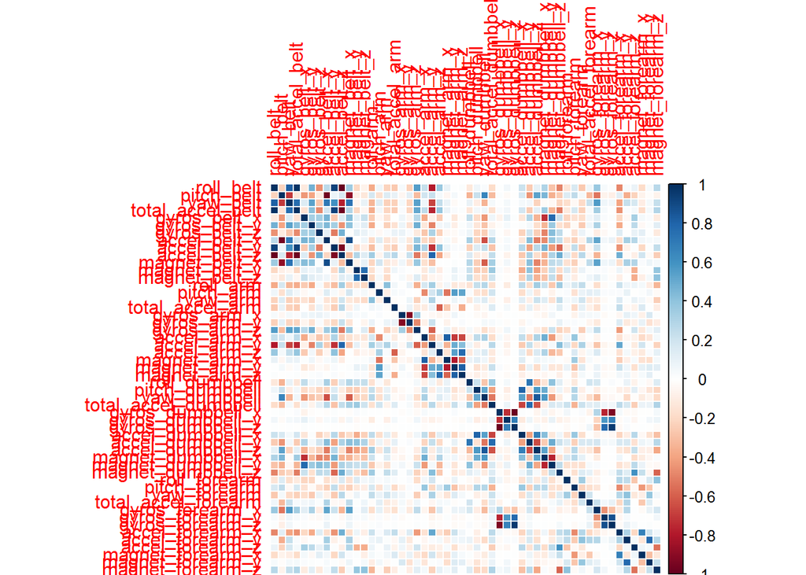

```r
#Correlation Matrix Visualization
corrPlot <- cor(p1[, -length(names(p1))])
corrplot(corrPlot, method="color")
```

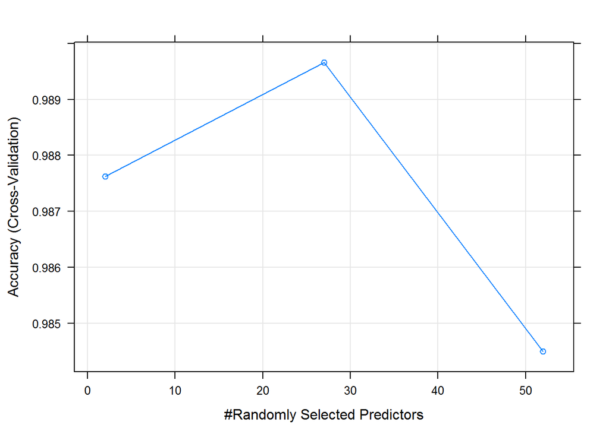

```r
#Plot for the partitioned training dataset with RandomForests Algorithm
plot(modelRf)
```

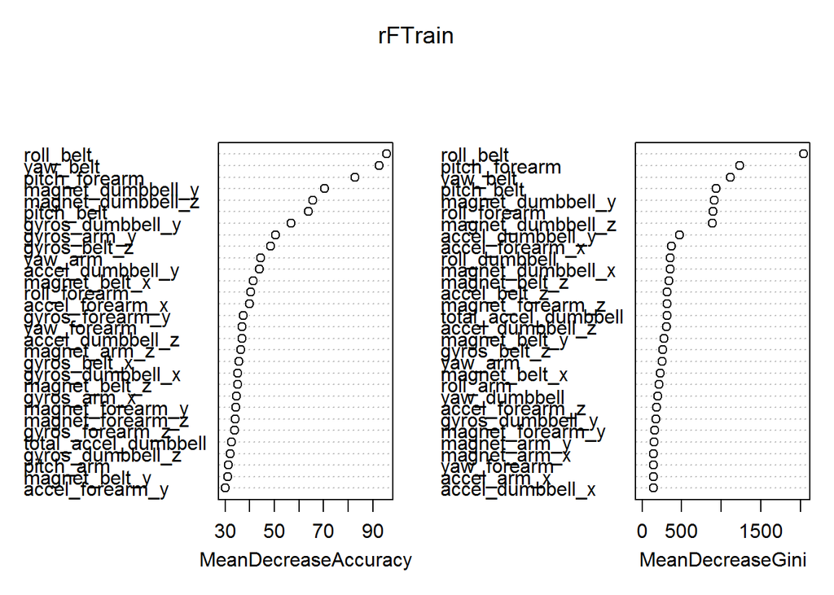

```r
#Plot for the full training dataset with RandomForests Algorithm
varImpPlot(rFTrain)
```

**Conclusion**

The Random Forests algorithm appears to perform very well for predicting activities from accelerometers measurements.